# Decision Trees

*Tree-based models* are a class of nonparametric algorithms that work by partitioning the feature space into a number of smaller (non-overlapping) regions with similar response values using a set of *splitting rules*. Predictions are obtained by fitting a simpler model (e.g., a constant like the average response value) in each region. Such *divide-and-conquer* methods can produce simple rules that are easy to interpret and visualize with *tree diagrams*. As we’ll see, decision trees offer many benefits; however, they typically lack in predictive performance compared to more complex algorithms like neural networks and MARS. However, future modules will discuss powerful ensemble algorithms—like random forests and gradient boosting machines—which are constructed by combining together many decision trees in a clever way. This module will provide you with a strong foundation in decision trees.

## Prerequisites

In this module we’ll use the following packages:

```r
# Helper packages
library(dplyr)       # for data wrangling
library(ggplot2)     # for awesome plotting

# Modeling packages
library(rpart)       # direct engine for decision tree application
library(caret)       # meta engine for decision tree application

# Model interpretability packages
library(rpart.plot)  # for plotting decision trees
library(vip)         # for feature importance
library(pdp)         # for feature effects
```

We’ll continue to illustrate the main concepts using the Ames housing example.

```r
# Create training (70%) set for the Ames housing data.
ames <- AmesHousing::make_ames()
set.seed(123)
split  <- rsample::initial_split(ames, prop = 0.7, strata = "Sale_Price")
ames_train  <- rsample::training(split)
```

# Structure

There are many methodologies for constructing decision trees but the most well-known is the **c**lassification **a**nd **r**egression **t**ree (CART) algorithm proposed in Breiman (1984).[^1] A basic decision tree partitions the training data into homogeneous subgroups (i.e., groups with similar response values) and then fits a simple *constant* in each subgroup (e.g., the mean of the within group response values for regression). The subgroups (also called nodes) are formed recursively using binary partitions formed by asking simple yes-or-no questions about each feature (e.g., is `age < 18`?). This is done a number of times until a suitable stopping criteria is satisfied (e.g., a maximum depth of the tree is reached). After all the partitioning has been done, the model predicts the output based on (1) the average response values for all observations that fall in that subgroup (regression problem), or (2) the class that has majority representation (classification problem). For classification, predicted probabilities can be obtained using the proportion of each class within the subgroup.

What results is an inverted tree-like structure such as that in the below figure. In essence, our tree is a set of rules that allows us to make predictions by asking simple yes-or-no questions about each feature. For example, if the customer is loyal, has household income greater than $150,000, and is shopping in a store, the exemplar tree diagram below would predict that the customer will redeem a coupon.

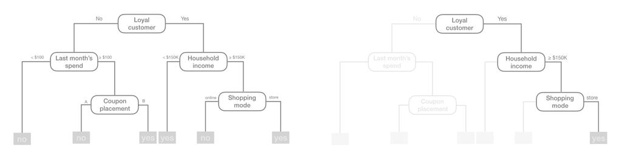

We refer to the first subgroup at the top of the tree as the *root node* (this node contains all of the training data). The final subgroups at the bottom of the tree are called the *terminal nodes* or *leaves*. Every subgroup in between is referred to as an internal node. The connections between nodes are called *branches*.

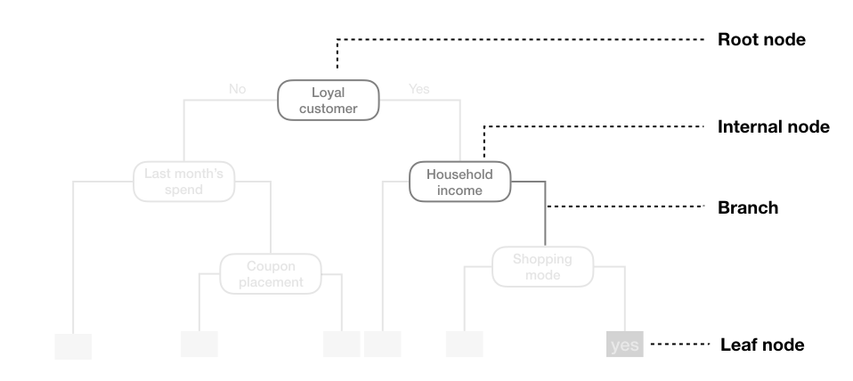

# Partitioning

As illustrated above, CART uses *binary recursive partitioning* (it’s recursive because each split or rule depends on the the splits above it). The objective at each node is to find the “best” feature ($x_i$) to partition the remaining data into one of two regions ($R_1$ and $R_2$) such that the overall error between the actual response ($y_i$) and the predicted constant ($c_i$) is minimized. For regression problems, the objective function to minimize is the total SSE as defined in the following equation:

$$\begin{equation}
SSE = \sum_{i \in R_1}\left(y_i - c_1\right)^2 + \sum_{i \in R_2}\left(y_i - c_2\right)^2
\end{equation}$$

For classification problems, the partitioning is usually made to maximize the reduction in cross-entropy or the Gini index (see [model evaluation](https://misk-data-science.github.io/misk-homl/docs/02-modeling-process.nb.html#classification_models)).[^2]

> *Note:* *In both regression and classification trees, the objective of partitioning is to minimize dissimilarity in the terminal nodes. However, we suggest Therneau, Atkinson, and others (1997) for a more thorough discussion regarding binary recursive partitioning.*

Having found the best feature/split combination, the data are partitioned into two regions and the splitting process is repeated on each of the two regions (hence the name binary recursive partitioning). This process is continued until a suitable stopping criterion is reached (e.g., a maximum depth is reached or the tree becomes “too complex”).

It’s important to note that a single feature can be used multiple times in a tree. For example, say we have data generated from a simple $\sin$ function with Gaussian noise: $Y_i \stackrel{iid}{\sim} N\left(\sin\left(X_i\right), \sigma^2\right)$, for $i = 1, 2, \dots, 500$. A regression tree built with a single root node (often referred to as a decision stump) leads to a split occurring at $x = 3.1$.

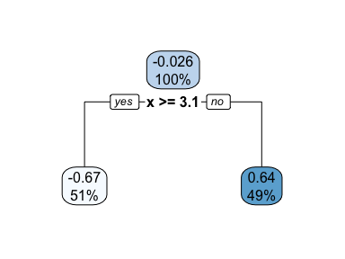

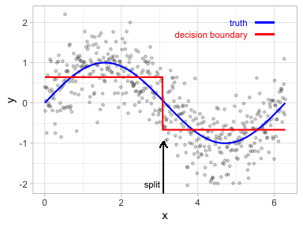

If we build a deeper tree, we’ll continue to split on the same feature ($x$) as illustrated below. This is because $x$ is the only feature available to split on so it will continue finding the optimal splits along this feature’s values until a pre-determined stopping criteria is reached.

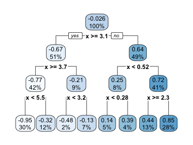

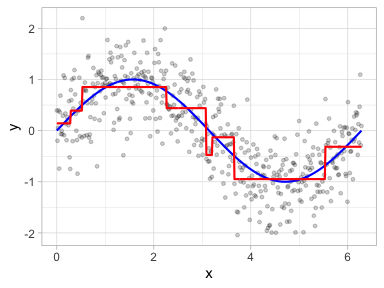

However, even when many features are available, a single feature may still dominate if it continues to provide the best split after each successive partition. For example, a decision tree applied to the iris data set (Fisher 1936) where the species of the flower (setosa, versicolor, and virginica) is predicted based on two features (sepal width and sepal length) results in an optimal decision tree with two splits on each feature. Also, note how the decision boundary in a classification problem results in rectangular regions enclosing the observations. The predicted value is the response class with the greatest proportion within the enclosed region.

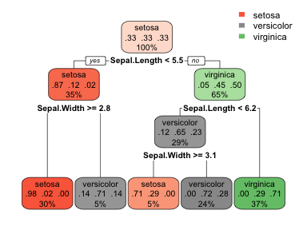

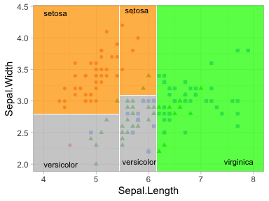

# How deep?

This leads to an important question: how deep (i.e., complex) should we make the tree? If we grow an overly complex tree as in the below figure, we tend to overfit to our training data resulting in poor generalization performance.

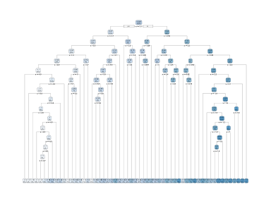

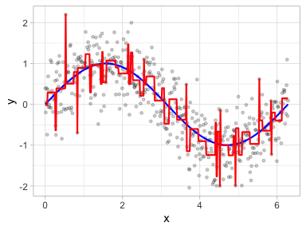

Consequently, there is a balance to be achieved in the depth and complexity of the tree to optimize predictive performance on future unseen data. To find this balance, we have two primary approaches: (1) early stopping and (2) pruning.

## Early stopping

Early stopping explicitly restricts the growth of the tree. There are several ways we can restrict tree growth but two of the most common approaches are to restrict the tree depth to a certain level or to restrict the minimum number of observations allowed in any terminal node. When limiting tree depth we stop splitting after a certain depth (e.g., only grow a tree that has a depth of 5 levels). The shallower the tree the less variance we have in our predictions; however, at some point we can start to inject too much bias as shallow trees (e.g., stumps) are not able to capture interactions and complex patterns in our data.

When restricting minimum terminal node size (e.g., leaf nodes must contain at least 10 observations for predictions) we are deciding to not split intermediate nodes which contain too few data points. At the far end of the spectrum, a terminal node’s size of one allows for a single observation to be captured in the leaf node and used as a prediction (in this case, we’re interpolating the training data). This results in high variance and poor generalizability. On the other hand, large values restrict further splits therefore reducing variance.

These two approaches can be implemented independently of one another; however, they do have interaction effects as illustrated below.

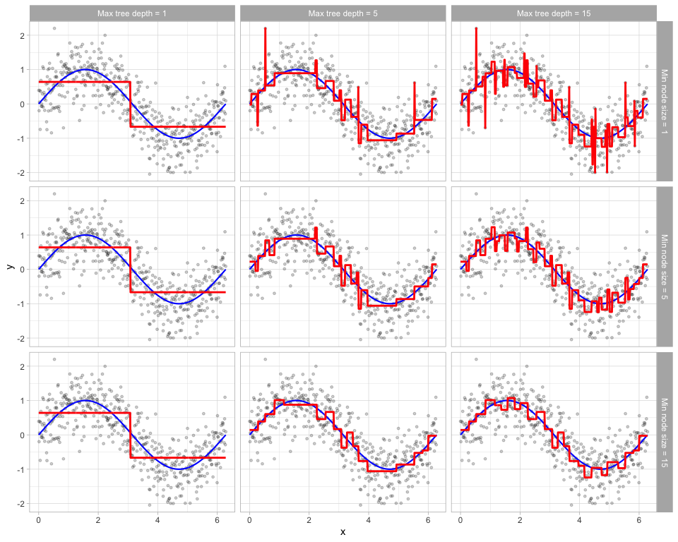

## Pruning

An alternative to explicitly specifying the depth of a decision tree is to grow a very large, complex tree and then *prune* it back to find an optimal subtree. We find the optimal subtree by using a *cost complexity parameter* ($\alpha$) that penalizes our objective function for the number of terminal nodes of the tree ($T$) as in the following equation.

$$\begin{equation}
\texttt{minimize} \left\{ SSE + \alpha \vert T \vert \right\}
\end{equation}$$

For a given value of $\alpha$ we find the smallest pruned tree that has the lowest penalized error. You may recognize the close association to the lasso penalty discussed in the [regularized regression module](https://misk-data-science.github.io/misk-homl/docs/06-regularized-regression.nb.html#lasso_penalty). As with the regularization methods, smaller penalties tend to produce more complex models, which result in larger trees. Whereas larger penalties result in much smaller trees. Consequently, as a tree grows larger, the reduction in the SSE must be greater than the cost complexity penalty. Typically, we evaluate multiple models across a spectrum of $\alpha$ and use CV to identify the optimal value and, therefore, the optimal subtree that generalizes best to unseen data.

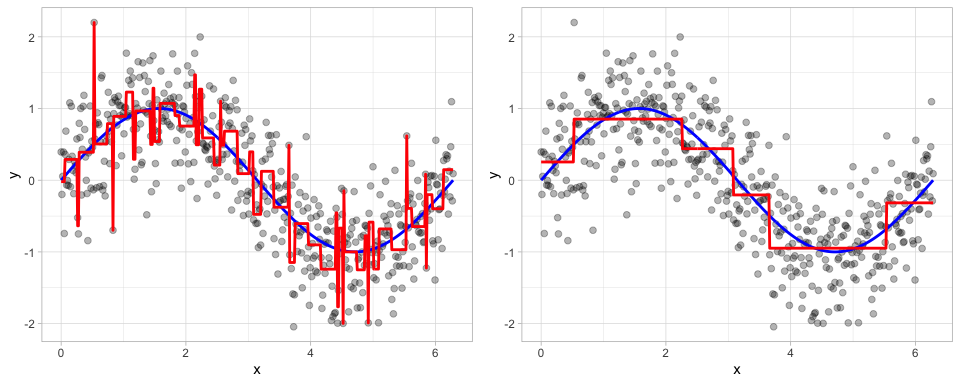

# Ames housing example

We can fit a regression tree using `rpart` and then visualize it using `rpart.plot`. The fitting process and the visual output of regression trees and classification trees are very similar. Both use the formula method for expressing the model (similar to `lm()`). However, when fitting a regression tree, we need to set `method = "anova"`. By default, `rpart()` will make an intelligent guess as to what method to use based on the data type of your response column, but it’s good practice to set this explicitly.

```r
ames_dt1 <- rpart(
  formula = Sale_Price ~ .,
  data    = ames_train,
  method  = "anova"
)
```

Once we’ve fit our model we can take a peak at the decision tree output. This prints various information about the different splits. For example, we start with `2053` observations at the root node and the first variable we split on (i.e., the first variable gave the largest reduction in SSE) is `Overall_Qual`. We see that at the first node all observations with `Overall_Qual` $\in$ $\{$`Very_Poor`, `Poor`, `Fair`, `Below_Average`, `Average`, `Above_Average`, `Good`$\}$ go to the 2nd (`2)`) branch. The total number of observations that follow this branch (`1722`), their average sales price (`156955`) and SSE (`4.1079e+12`) are listed. If you look for the 3rd branch (`3)`) you will see that `331` observations with `Overall_Qual` $\in$ $\{$`Very_Good`, `Excellent`, `Very_Excellent`$\}$ follow this branch and their average sales prices is `306071` and the SEE in this region is `2.9367e+12`. Basically, this is telling us that `Overall_Qual` is an important predictor on sales price with those homes on the upper end of the quality spectrum having almost double the average sales price.

```r
ames_dt1
```

```
n= 2053

node), split, n, deviance, yval
      * denotes terminal node

 1) root 2053 13217940000000 180996.30
   2) Overall_Qual=Very_Poor,Poor,Fair,Below_Average,Average,Above_Average,Good 1722  4107888000000 156954.70
     4) Neighborhood=North_Ames,Old_Town,Edwards,Sawyer,Mitchell,Brookside,Iowa_DOT_and_Rail_Road,South_and_West_of_Iowa_State_University,Meadow_Village,Briardale,Northpark_Villa,Blueste 1022  1332227000000 132318.00
       8) Overall_Qual=Very_Poor,Poor,Fair,Below_Average 199   179295400000  98856.51 *
       9) Overall_Qual=Average,Above_Average,Good 823   876239900000 140409.00
        18) First_Flr_SF< 1089 517   290531200000 129244.00 *
        19) First_Flr_SF>=1089 306   412375700000 159272.60 *
     5) Neighborhood=College_Creek,Somerset,Northridge_Heights,Gilbert,Northwest_Ames,Sawyer_West,Crawford,Timberland,Northridge,Stone_Brook,Clear_Creek,Bloomington_Heights,Veenker,Green_Hills 700  1249681000000 192924.20
      10) Gr_Liv_Area< 1477 287   250826800000 165395.90 *
      11) Gr_Liv_Area>=1477 413   630227700000 212054.00
        22) Total_Bsmt_SF< 959.5 199   139087700000 192493.10 *
        23) Total_Bsmt_SF>=959.5 214   344191200000 230243.70 *
   3) Overall_Qual=Very_Good,Excellent,Very_Excellent 331  2936700000000 306070.70
     6) Overall_Qual=Very_Good 231   946974600000 270626.10
      12) Gr_Liv_Area< 1919 142   334978300000 244016.60 *
      13) Gr_Liv_Area>=1919 89   351030800000 313081.60 *
     7) Overall_Qual=Excellent,Very_Excellent 100  1029126000000 387948.00
      14) Total_Bsmt_SF< 1907.5 72   314985900000 350532.40 *
      15) Total_Bsmt_SF>=1907.5 28   354159900000 484159.40 *
```

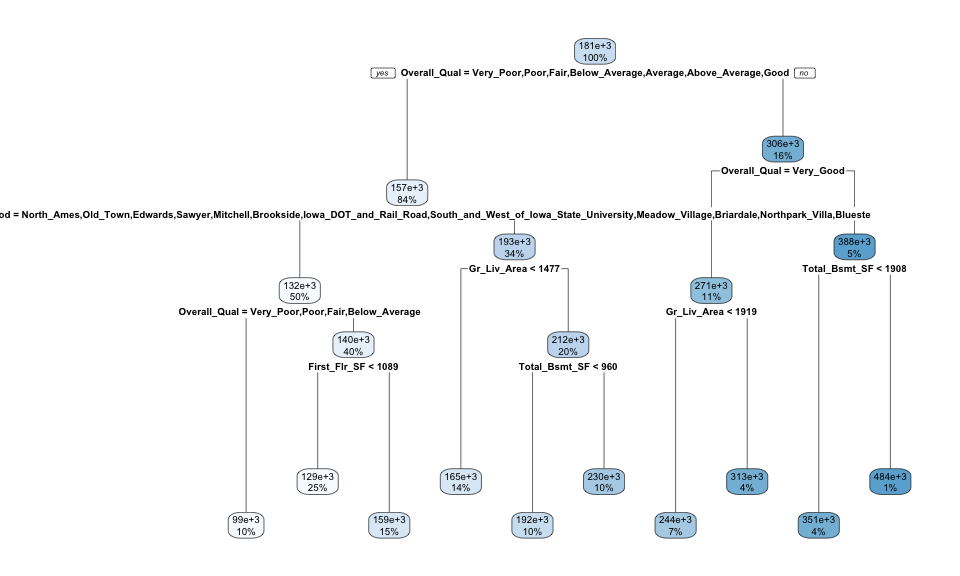

```r
rpart.plot(ames_dt1)
```

Behind the scenes `rpart()` is automatically applying a range of cost complexity ($\alpha$ values to prune the tree). To compare the error for each $\alpha$ value, `rpart()` performs a 10-fold CV (by default). In this example we find diminishing returns after `10` terminal nodes as illustrated below ($y$-axis is the CV error, lower $x$-axis is the cost complexity ($\alpha$) value, upper $x$-axis is the number of terminal nodes (i.e., tree size = $\vert T \vert$). You may also notice the dashed line which goes through the point $\vert T \vert = 8$. Breiman (1984) suggested that in actual practice, it’s common to instead use the smallest tree within 1 standard error (SE) of the minimum CV error (this is called the *1-SE rule*). Thus, we could use a tree with 8 terminal nodes and reasonably expect to experience similar results within a small margin of error.

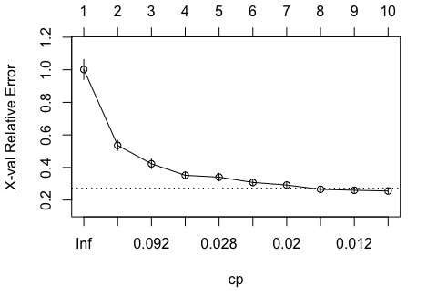

```r
plotcp(ames_dt1)
```

To illustrate the point of selecting a tree with 10 terminal nodes (or 8 if you go by the 1-SE rule), we can force `rpart()` to generate a full tree by setting `cp = 0` (no penalty results in a fully grown tree). The below plot shows that after 11 terminal nodes, we see diminishing returns in error reduction as the tree grows deeper. Thus, we can significantly prune our tree and still achieve minimal expected error.

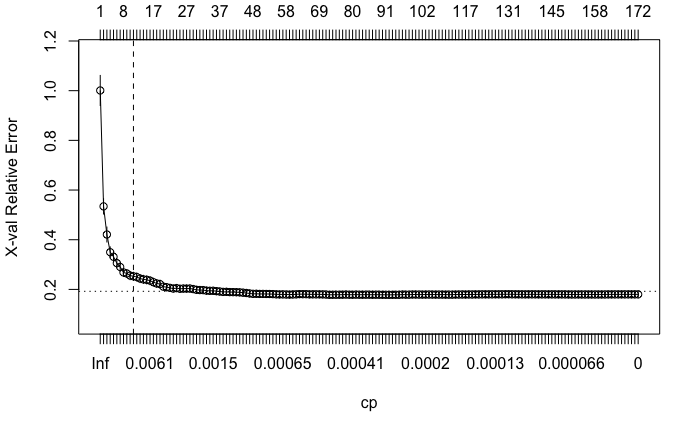

```r
ames_dt2 <- rpart(
    formula = Sale_Price ~ .,
    data    = ames_train,
    method  = "anova",
    control = list(cp = 0, xval = 10)
)

plotcp(ames_dt2)
abline(v = 11, lty = "dashed")
```

```r
# rpart cross validation results
ames_dt1$cptable
```

```
           CP nsplit rel error    xerror       xstd
1  0.46704344      0 1.0000000 1.0017384 0.06052277
2  0.11544770      1 0.5329566 0.5360199 0.03092381
3  0.07267387      2 0.4175089 0.4227062 0.03020494
4  0.02788834      3 0.3448350 0.3519859 0.02164335
5  0.02723422      4 0.3169466 0.3407817 0.02330150
6  0.02093301      5 0.2897124 0.3081172 0.02073843
7  0.01974328      6 0.2687794 0.2921817 0.01865720
8  0.01311346      7 0.2490361 0.2658829 0.01768048
9  0.01111737      8 0.2359227 0.2600123 0.01752021
10 0.01000000      9 0.2248053 0.2557926 0.01789300
```

```r
# caret cross validation results
ames_dt3 <- train(
  Sale_Price ~ .,
  data = ames_train,
  method = "rpart",
  trControl = trainControl(method = "cv", number = 10),
  tuneLength = 20
)
```

```
There were missing values in resampled performance measures.
```

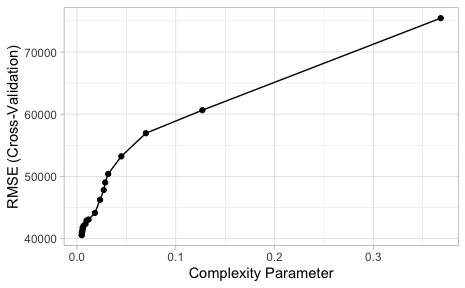

```r
ggplot(ames_dt3)
```

# Feature interpretation

To measure feature importance, the reduction in the loss function (e.g., SSE) attributed to each variable at each split is tabulated. In some instances, a single variable could be used multiple times in a tree; consequently, the total reduction in the loss function across all splits by a variable are summed up and used as the total feature importance. When using **caret**, these values are standardized so that the most important feature has a value of 100 and the remaining features are scored based on their relative reduction in the loss function. Also, since there may be candidate variables that are important but are not used in a split, the top competing variables are also tabulated at each split.

The plot below illustrates the top 45 features in the Ames housing decision tree. Similar to MARS, decision trees perform automated feature selection where uninformative features are not used in the model. We can see this below where the bottom six features in the plot have zero importance.

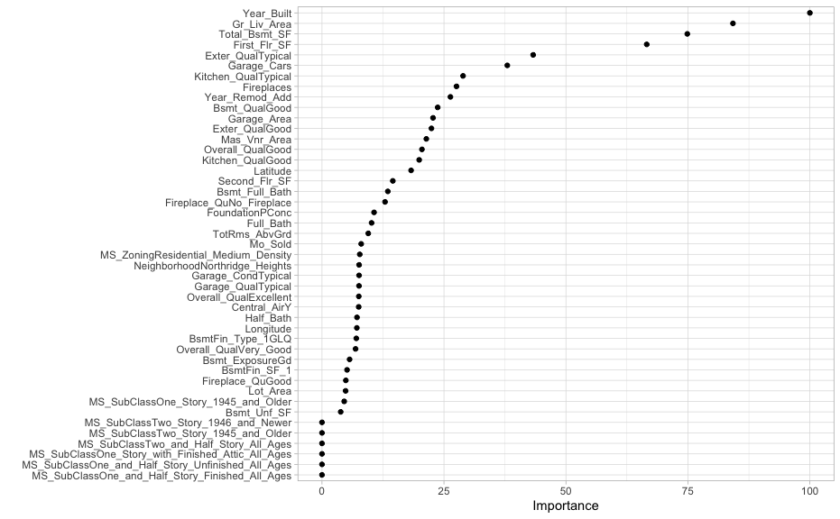

```r
vip(ames_dt3, num_features = 45, geom = "point")
```

If we look at the same partial dependence plots that we created for the MARS models, we can see the similarity in how decision trees are modeling the relationship between the features and target. In the plots below, we see that `Gr_Liv_Area` has a non-linear relationship on the predicted sales price for `Gr_liv_Area` values between 1400–2300 but then has little, if any, influence when it exceeds 2300. However, the 3-D plot of the interaction effect between `Gr_Liv_Area` and `Year_Built` illustrates a key difference in how decision trees have rigid non-smooth prediction surfaces compared to MARS; in fact, MARS was developed as an improvement to CART for regression problems.

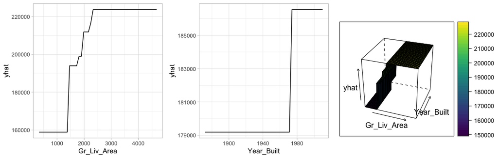

```r
# Construct partial dependence plots
p1 <- partial(ames_dt3, pred.var = "Gr_Liv_Area") %>%
  ggplot(aes(Gr_Liv_Area, yhat)) +
  geom_line()

p2 <- partial(ames_dt3, pred.var = "Year_Built") %>%
  ggplot(aes(Year_Built, yhat)) +
  geom_line()

p3 <- partial(ames_dt3, pred.var = c("Gr_Liv_Area", "Year_Built")) %>%
  plotPartial(levelplot = FALSE, zlab = "yhat", drape = TRUE,
              colorkey = TRUE, screen = list(z = -20, x = -60))

# Display plots side by side
gridExtra::grid.arrange(p1, p2, p3, ncol = 3)
```

# Final thoughts

Decision trees have a number of advantages. Trees require very little pre-processing. This is not to say feature engineering may not improve upon a decision tree, but rather, that there are no pre-processing requirements. Monotonic transformations (e.g., $\log$, $\exp$, and $\sqrt{}$) are not required to meet algorithm assumptions as in many parametric models; instead, they only shift the location of the optimal split points. Outliers typically do not bias the results as much since the binary partitioning simply looks for a single location to make a split within the distribution of each feature.

Decision trees can easily handle categorical features without preprocessing. For unordered categorical features with more than two levels, the classes are ordered based on the outcome (for regression problems, the mean of the response is used and for classification problems, the proportion of the positive outcome class is used). For more details see Friedman, Hastie, and Tibshirani (2001), Breiman and Ihaka (1984), Ripley (2007), Fisher (1958), and Loh and Vanichsetakul (1988).

Missing values often cause problems with statistical models and analyses. Most procedures deal with them by refusing to deal with them—incomplete observations are tossed out. However, most decision tree implementations can easily handle missing values in the features and do not require imputation. This is handled in various ways but most commonly by creating a new “missing” class for categorical variables or using surrogate splits (see Therneau, Atkinson, and others (1997) for details).

However, individual decision trees generally do not often achieve state-of-the-art predictive accuracy. In this module, we saw that the best pruned decision tree, although it performed better than linear regression, had a very poor RMSE ($41,019) compared to some of the other models we’ve built. This is driven by the fact that decision trees are composed of simple yes-or-no rules that create rigid non-smooth decision boundaries. Furthermore, we saw that deep trees tend to have high variance (and low bias) and shallow trees tend to be overly bias (but low variance). In the modules that follow, we’ll see how we can combine multiple trees together into very powerful prediction models called *ensembles*.

# Python

The following resources provide detailed examples of performing decision trees with Python and Scikit Learn:

- Jordan Crouser’s [lab notebook](http://www.science.smith.edu/~jcrouser/SDS293/labs/lab14-py.html) on decision trees for Smith College Machine Learning course. For now, only focus on the first two sections (8.3.1-8.3.2).
- Chris Albon’s tutorials on using decision trees for [classification](https://chrisalbon.com/machine_learning/trees_and_forests/decision_tree_classifier/) and [regression](https://chrisalbon.com/machine_learning/trees_and_forests/decision_tree_regression/).
- Chapter 6 of [Hands-On Machine Learning with Scikit-Learn, Keras, and TensorFlow](https://www.amazon.com/Hands-Machine-Learning-Scikit-Learn-TensorFlow-dp-1492032646/dp/1492032646/ref=dp_ob_title_bk) and the accompanying publicly available [jupyter notebook](https://github.com/ageron/handson-ml2/blob/master/06_decision_trees.ipynb) regarding decision trees.

# Exercises

Using the Boston housing data set from the pdp package, where the response feature is the median value of homes within a census tract (`cmedv`):

1. Apply a decision tree model with all features.
2. How many internal splitting nodes optimize model performance?
3. What are the predicted values and SEE in the terminal nodes?
4. Identify the first feature split node and explain how it is splitting this feature.
5. Which 10 features are considered most influential? Are these the same features that have been influential in previous models?
6. Now perform 1-5 to the Attrition dataset, which is classification model rather than a regression model.
7. **Python challenge**: Repeat the above exercises but using Python and Scikit Learn. Recall that Scikit Learn [provides the Boston housing data set](https://chrisalbon.com/machine_learning/basics/loading_scikit-learns_boston_housing_dataset/).

[🏠](https://github.com/misk-data-science/misk-homl)

# References

Breiman, Leo. 1984. *Classification and Regression Trees*. Routledge.

Breiman, Leo, and Ross Ihaka. 1984. *Nonlinear Discriminant Analysis via Scaling and Ace*. Department of Statistics, University of California.

Fisher, Ronald A. 1936. “The Use of Multiple Measurements in Taxonomic Problems.” *Annals of Eugenics* 7 (2). Wiley Online Library: 179–88.

Fisher, Walter D. 1958. “On Grouping for Maximum Homogeneity.” *Journal of the American Statistical Association* 53 (284). Taylor & Francis: 789–98.

Friedman, Jerome, Trevor Hastie, and Robert Tibshirani. 2001. *The Elements of Statistical Learning*. Vol. 1. Springer Series in Statistics New York, NY, USA:

Hothorn, Torsten, Kurt Hornik, and Achim Zeileis. 2006. “Unbiased Recursive Partitioning: A Conditional Inference Framework.” *Journal of Computational and Graphical Statistics* 15 (3). Taylor & Francis: 651–74.

Kass, Gordon V. 1980. “An Exploratory Technique for Investigating Large Quantities of Categorical Data.” *Applied Statistics*. JSTOR, 119–27.

Loh, Wei-Yin, and Nunta Vanichsetakul. 1988. “Tree-Structured Classification via Generalized Discriminant Analysis.” *Journal of the American Statistical Association* 83 (403). Taylor & Francis Group: 715–25.

Quinlan, J. Ross. 1986. “Induction of Decision Trees.” *Machine Learning* 1 (1). Springer: 81–106.

Quinlan, J Ross, and others. 1996. “Bagging, Boosting, and C4. 5.” In *AAAI/Iaai, Vol. 1*, 725–30.

Ripley, Brian D. 2007. *Pattern Recognition and Neural Networks*. Cambridge University Press.

Therneau, Terry M, Elizabeth J Atkinson, and others. 1997. “An Introduction to Recursive Partitioning Using the RPART Routines.” Mayo Foundation.

[^1]: Other decision tree algorithms include the Iterative Dichotomiser 3 (Quinlan 1986), C4.5 (Quinlan and others 1996), Chi-square automatic interaction detection (Kass 1980), Conditional inference trees (Hothorn, Hornik, and Zeileis 2006), and more.
[^2]: Gini index and cross-entropy are the two most commonly applied loss functions used for decision trees. Classification error is rarely used to determine partitions as they are less sensitive to poor performing splits (Friedman, Hastie, and Tibshirani 2001).